# 🧠 Behavioral Analytics for Funnel Drop-Off Recovery in Fintech

## 🎯 Project Overview

This project simulates and analyzes a digital banking funnel to identify behavioral patterns, drop-off points, and revenue recovery opportunities.

I integrated user activity across:

- Funnel progression steps (Sign-Up → KYC → Link → Transaction)
- Transaction behavior (Open Banking Style)
- Support interaction logs

Clustering is applied to segment users based on behavior, visualize where friction occurs, and simulate the financial upside of improving user journeys.

**Tools Used**: Python, Pandas, Matplotlib, Scikit-learn (KMeans)

> 📌 This project mimics the role of a product or fintech data analyst responsible for identifying where customers fall off, what behavioral patterns matter, and how to prioritize UX improvements with measurable business value.

## 📁 Step 1: Simulate Multi-Source Funnel Data

I simulated 1,000 users moving through a 4-step funnel:

1. Sign-Up
2. KYC Completion
3. Account Linking
4. Transaction

And also simulated:

- `txn_log`: completed transaction amounts
- `support_log`: support tickets with issue types

These datasets represent backend events, transaction APIs, and CRM data in a realistic product setting.

```python
import pandas as pd
import numpy as np
import random
from datetime import datetime, timedelta

# Set random seed for reproducibility
np.random.seed(42)

# 1. Simulate 1000 users
num_users = 1000
user_ids = [f"U{str(i).zfill(4)}" for i in range(1, num_users + 1)]

# Random signup dates (within the first 6 months of 2023)
start_date = datetime(2023, 1, 1)
signup_dates = [start_date + timedelta(days=np.random.randint(0, 180)) for _ in user_ids]

# 2. Simulate funnel progression with completion rates
def simulate_step_dates(base_dates, completion_rate, min_delay=1, max_delay=10):
    step_flags = []
    step_dates = []
    for date in base_dates:
        if date is not None and random.random() < completion_rate:
            delay = timedelta(days=random.randint(min_delay, max_delay))
            step_date = date + delay
            step_flags.append(1)
            step_dates.append(step_date)
        else:
            step_flags.append(0)
            step_dates.append(None)
    return step_flags, step_dates


# Simulate funnel steps
kyc_flags, kyc_dates = simulate_step_dates(signup_dates, 0.85, 1, 5)  # 85% complete KYC
link_flags, link_dates = simulate_step_dates(kyc_dates, 0.75, 1, 7)    # 75% link account
txn_flags, txn_dates = simulate_step_dates(link_dates, 0.60, 1, 14)    # 60% complete transaction

# 3. Create the funnel dataset
funnel_df = pd.DataFrame({
    "User_ID": user_ids,
    "Signup_Date": signup_dates,
    "KYC_Completed": kyc_flags,
    "KYC_Date": kyc_dates,
    "Account_Linked": link_flags,
    "Link_Date": link_dates,
    "Transaction_Completed": txn_flags,
    "Transaction_Date": txn_dates
})

# 4. Create the transaction log dataset
txn_log = funnel_df[funnel_df["Transaction_Completed"] == 1][["User_ID", "Transaction_Date"]].copy()
txn_log["Transaction_Amount"] = np.random.gamma(shape=2.5, scale=200, size=len(txn_log)).round(2)

# 5. Create the support ticket log dataset (sample 20% users)
support_log = funnel_df.sample(frac=0.20).copy()
support_log["Support_Date"] = support_log["Signup_Date"] + pd.to_timedelta(np.random.randint(2, 30, size=len(support_log)), unit="d")
support_log["Issue_Type"] = np.random.choice(["KYC Delay", "Link Failure", "App Bug", "Trust Issue"], size=len(support_log))

# Show preview of the datasets
funnel_df.head(), txn_log.head(), support_log.head()
```

```
(  User_ID Signup_Date  KYC_Completed   KYC_Date  Account_Linked  Link_Date  \
 0   U0001  2023-04-13              1 2023-04-16               1 2023-04-23
 1   U0002  2023-06-29              1 2023-06-30               1 2023-07-03
 2   U0003  2023-04-03              0        NaT               0        NaT
 3   U0004  2023-01-15              1 2023-01-18               1 2023-01-23
 4   U0005  2023-04-17              1 2023-04-19               1 2023-04-23

    Transaction_Completed Transaction_Date
 0                      1       2023-05-03
 1                      1       2023-07-10
 2                      0              NaT
 3                      0              NaT
 4                      1       2023-05-01  ,
   User_ID Transaction_Date  Transaction_Amount
 0   U0001       2023-05-03              661.27
```

[output cut: 17 more lines]

## 🔧 Step 2: Merge and Feature Engineering

I merged the funnel, transaction, and support datasets into a unified `merged_df`. From this, I engineered new features:

| Feature | Description |
| --- | --- |
| `Time_to_KYC` | Days from sign-up to KYC |
| `Time_KYC_to_Link` | Days from KYC to account linking |
| `Time_Link_to_Txn` | Days from account linking to transaction |
| `Support_Contacted` | 1 if user contacted support |

Drop-outs at each step were captured using a value of `-1`.

```python
# STEP 2: Merge funnel, transaction, and support logs

# 1. Merge transaction data into funnel data
merged_df = funnel_df.merge(txn_log, on="User_ID", how="left")

# 2. Rename to avoid confusion
merged_df.rename(columns={"Transaction_Date_y": "Transaction_Date_Final",
                          "Transaction_Amount": "Txn_Amount",
                          "Transaction_Date_x": "Transaction_Date"}, inplace=True)

# 3. Merge support log into the merged data
merged_df = merged_df.merge(support_log[["User_ID", "Support_Date", "Issue_Type"]], on="User_ID", how="left")

# Preview the merged dataset
merged_df.head()
```

|  | User_ID | Signup_Date | KYC_Completed | KYC_Date | Account_Linked | Link_Date | Transaction_Completed | Transaction_Date | Transaction_Date_Final | Txn_Amount | Support_Date | Issue_Type |
| --- | --- | --- | --- | --- | --- | --- | --- | --- | --- | --- | --- | --- |
| 0 | U0001 | 2023-04-13 | 1 | 2023-04-16 | 1 | 2023-04-23 | 1 | 2023-05-03 | 2023-05-03 | 661.27 | 2023-04-18 | App Bug |
| 1 | U0002 | 2023-06-29 | 1 | 2023-06-30 | 1 | 2023-07-03 | 1 | 2023-07-10 | 2023-07-10 | 379.98 | NaT | NaN |
| 2 | U0003 | 2023-04-03 | 0 | NaT | 0 | NaT | 0 | NaT | NaT | NaN | NaT | NaN |
| 3 | U0004 | 2023-01-15 | 1 | 2023-01-18 | 1 | 2023-01-23 | 0 | NaT | NaT | NaN | NaT | NaN |
| 4 | U0005 | 2023-04-17 | 1 | 2023-04-19 | 1 | 2023-04-23 | 1 | 2023-05-01 | 2023-05-01 | 627.23 | NaT | NaN |

```python
# STEP 2: Merge funnel, transaction, and support logs

# 1. Merge transaction log
merged_df = funnel_df.merge(txn_log, on="User_ID", how="left")

# 2. Rename transaction columns
merged_df.rename(columns={
    "Transaction_Date_y": "Transaction_Date_Final",
    "Transaction_Amount": "Txn_Amount",
    "Transaction_Date_x": "Transaction_Date"
}, inplace=True)

# 3. Merge support ticket log
merged_df = merged_df.merge(support_log[["User_ID", "Support_Date", "Issue_Type"]], on="User_ID", how="left")

# 4. Feature engineering: time between funnel steps
merged_df['Time_to_KYC'] = (pd.to_datetime(merged_df['KYC_Date']) - pd.to_datetime(merged_df['Signup_Date'])).dt.days
merged_df['Time_KYC_to_Link'] = (pd.to_datetime(merged_df['Link_Date']) - pd.to_datetime(merged_df['KYC_Date'])).dt.days
merged_df['Time_Link_to_Txn'] = (pd.to_datetime(merged_df['Transaction_Date_Final']) - pd.to_datetime(merged_df['Link_Date'])).dt.days

# 5. Handle missing values
merged_df['Time_to_KYC'] = merged_df['Time_to_KYC'].fillna(-1)
merged_df['Time_KYC_to_Link'] = merged_df['Time_KYC_to_Link'].fillna(-1)
merged_df['Time_Link_to_Txn'] = merged_df['Time_Link_to_Txn'].fillna(-1)

# 6. Support flag
merged_df['Support_Contacted'] = merged_df['Issue_Type'].apply(lambda x: 1 if pd.notnull(x) else 0)

# 7. Show the final result
merged_df.head()
```

|  | User_ID | Signup_Date | KYC_Completed | KYC_Date | Account_Linked | Link_Date | Transaction_Completed | Transaction_Date | Transaction_Date_Final | Txn_Amount | Support_Date | Issue_Type | Time_to_KYC | Time_KYC_to_Link | Time_Link_to_Txn | Support_Contacted |
| --- | --- | --- | --- | --- | --- | --- | --- | --- | --- | --- | --- | --- | --- | --- | --- | --- |
| 0 | U0001 | 2023-04-13 | 1 | 2023-04-16 | 1 | 2023-04-23 | 1 | 2023-05-03 | 2023-05-03 | 661.27 | 2023-04-18 | App Bug | 3.0 | 7.0 | 10.0 | 1 |
| 1 | U0002 | 2023-06-29 | 1 | 2023-06-30 | 1 | 2023-07-03 | 1 | 2023-07-10 | 2023-07-10 | 379.98 | NaT | NaN | 1.0 | 3.0 | 7.0 | 0 |
| 2 | U0003 | 2023-04-03 | 0 | NaT | 0 | NaT | 0 | NaT | NaT | NaN | NaT | NaN | -1.0 | -1.0 | -1.0 | 0 |
| 3 | U0004 | 2023-01-15 | 1 | 2023-01-18 | 1 | 2023-01-23 | 0 | NaT | NaT | NaN | NaT | NaN | 3.0 | 5.0 | -1.0 | 0 |
| 4 | U0005 | 2023-04-17 | 1 | 2023-04-19 | 1 | 2023-04-23 | 1 | 2023-05-01 | 2023-05-01 | 627.23 | NaT | NaN | 2.0 | 4.0 | 8.0 | 0 |

**🧠 Interpretation:** A full user-level journey was built with friction signals. Dropouts were marked using `-1`, maintaining behavior patterns.

### 🔹 Step 2.3: Funnel Exploration & Support Impact

```python
# ✅ 1. How many users completed each funnel stage?
funnel_counts = {
    "Total Users": len(merged_df),
    "KYC Completed": merged_df['KYC_Completed'].sum(),
    "Account Linked": merged_df['Account_Linked'].sum(),
    "Transaction Completed": merged_df['Transaction_Completed'].sum(),
    "Contacted Support": merged_df['Support_Contacted'].sum()
}
print("🔢 Funnel Completion Counts:")
for k, v in funnel_counts.items():
    print(f"{k}: {v}")

# ✅ 2. Average time to complete each funnel step (only among those who completed it)
avg_time_kyc = merged_df[merged_df['Time_to_KYC'] >= 0]['Time_to_KYC'].mean()
avg_time_link = merged_df[merged_df['Time_KYC_to_Link'] >= 0]['Time_KYC_to_Link'].mean()
avg_time_txn = merged_df[merged_df['Time_Link_to_Txn'] >= 0]['Time_Link_to_Txn'].mean()

print("\n⏱️ Average Time Between Steps:")
print(f"Signup → KYC: {avg_time_kyc:.1f} days")
print(f"KYC → Link:   {avg_time_link:.1f} days")
print(f"Link → Txn:   {avg_time_txn:.1f} days")

# ✅ 3. Compare average total time for users who contacted support vs not
merged_df["Total_Time_to_Txn"] = merged_df[['Time_to_KYC', 'Time_KYC_to_Link', 'Time_Link_to_Txn']].apply(
    lambda row: sum([x for x in row if x >= 0]), axis=1)

avg_time_support = merged_df[merged_df['Support_Contacted'] == 1]["Total_Time_to_Txn"].mean()
avg_time_nosupport = merged_df[merged_df['Support_Contacted'] == 0]["Total_Time_to_Txn"].mean()

print("\n📞 Support Comparison:")
print(f"Users who contacted support:   {avg_time_support:.1f} days to complete")
print(f"Users who did NOT contact support: {avg_time_nosupport:.1f} days")
```

```
🔢 Funnel Completion Counts:
Total Users: 1000
KYC Completed: 814
Account Linked: 607
Transaction Completed: 367
Contacted Support: 200

⏱️ Average Time Between Steps:
Signup → KYC: 2.9 days
KYC → Link:   3.9 days
Link → Txn:   7.4 days

📞 Support Comparison:
Users who contacted support:   7.3 days to complete
Users who did NOT contact support: 7.5 days
```

🔍 Insight: Even in a simulated flow, the pattern is clear: Conversion rates drop sharply after KYC, and even more after account linking. Support touch doesn’t delay users — it may even assist slightly.

✅ Real-world implication: Speed alone doesn’t guarantee conversion — trust and motivation matter at later steps The final step (Link → Transaction) is the bottleneck for most users

### 🔹 Step 3.1–3.2: Clustering & Segment Profiling

Applied `KMeans` with 3 clusters:

- Features: delay times, support, conversion
- Replaced drop-off delays (`-1`) with `99` to retain signal

```python
# ✅ Step 3.1: Prepare Data and Cluster Users

from sklearn.preprocessing import StandardScaler
from sklearn.cluster import KMeans

# 1. Select behavior features for clustering
clustering_df = merged_df[[
    'Time_to_KYC',
    'Time_KYC_to_Link',
    'Time_Link_to_Txn',
    'Support_Contacted',
    'Transaction_Completed'
]].copy()

# 2. Replace -1 (meaning they didn't complete a step) with 99 (high delay)
clustering_df[['Time_to_KYC', 'Time_KYC_to_Link', 'Time_Link_to_Txn']] = clustering_df[[
    'Time_to_KYC', 'Time_KYC_to_Link', 'Time_Link_to_Txn'
]].replace(-1, 99)

# 3. Handle any missing values
clustering_df.fillna(99, inplace=True)

# 4. Standardize all features (so KMeans treats them equally)
scaler = StandardScaler()
X_scaled = scaler.fit_transform(clustering_df)

# 5. Apply KMeans clustering to group similar users (we’ll start with 3 clusters)
kmeans = KMeans(n_clusters=3, random_state=42, n_init=10)
clusters = kmeans.fit_predict(X_scaled)

# 6. Add cluster labels back to the main dataset
merged_df['User_Segment'] = clusters

# 7. Preview the clustered data
merged_df[['User_ID', 'User_Segment', 'Time_to_KYC', 'Time_KYC_to_Link', 'Time_Link_to_Txn',
           'Support_Contacted', 'Transaction_Completed']].head()
```

|  | User_ID | User_Segment | Time_to_KYC | Time_KYC_to_Link | Time_Link_to_Txn | Support_Contacted | Transaction_Completed |
| --- | --- | --- | --- | --- | --- | --- | --- |
| 0 | U0001 | 1 | 3.0 | 7.0 | 10.0 | 1 | 1 |
| 1 | U0002 | 1 | 1.0 | 3.0 | 7.0 | 0 | 1 |
| 2 | U0003 | 2 | -1.0 | -1.0 | -1.0 | 0 | 0 |
| 3 | U0004 | 0 | 3.0 | 5.0 | -1.0 | 0 | 0 |
| 4 | U0005 | 1 | 2.0 | 4.0 | 8.0 | 0 | 1 |

## 🔍 Segment Interpretation Based on Behavioural Metrics

### 🔴 **Segment 2: Did Nothing After Sign-Up (Early Exit)**

| Feature | Value | Meaning |
| --- | --- | --- |
| `Conversion_Rate` | 0.0 | ❌ No one transacted |
| `Median_Time_to_KYC` | -1 | Didn’t complete even KYC |
| `All Time Columns` | -1 | All indicate no progress |
| `Support_Rate` | 0.17 | Low — didn’t even ask for help |

🧠 **Logic:** These users never engaged beyond sign-up.  
They didn’t convert, didn’t try, and didn’t reach out for help.

> *This is an “early exit” segment — users drop out right after joining.*

### 🟡 **Segment 0: Got Close, But Didn’t Convert (Late Exit)**

[output not shown]

> *This is a high-potential but high-friction segment — ideal for product improvement.*

### 🟢 **Segment 1: Completed the Funnel Successfully**

| Feature | Value | Meaning |
| --- | --- | --- |
| `Conversion_Rate` | 1.0 | ✅ 100% converted |
| `Median_Time_to_KYC` | 2.9 | ✅ Fast progression |
| `Median_KYC_to_Link` | 3.9 | ✅ Moderate time delay |
| `Median_Link_to_Txn` | 7.4 | ✅ Completed full journey |
| `Support_Rate` | 0.19 | Support was optional |

🧠 **Logic:** These users are your “happy path” — they converted fully with minimal support.

> *This is your ideal segment — learn from their experience and replicate it.*

```python
# Show segment distribution and a preview of 10 random users
print("🧠 Users per segment:")
print(merged_df['User_Segment'].value_counts())

# Show a sample of users with key behavior columns
merged_df[['User_ID', 'User_Segment', 'Time_to_KYC', 'Time_KYC_to_Link',
           'Time_Link_to_Txn', 'Support_Contacted', 'Transaction_Completed']].sample(10)
```

```
🧠 Users per segment:
User_Segment
0    447
1    367
2    186
Name: count, dtype: int64
```

|  | User_ID | User_Segment | Time_to_KYC | Time_KYC_to_Link | Time_Link_to_Txn | Support_Contacted | Transaction_Completed |
| --- | --- | --- | --- | --- | --- | --- | --- |
| 816 | U0817 | 2 | -1.0 | -1.0 | -1.0 | 1 | 0 |
| 391 | U0392 | 1 | 4.0 | 4.0 | 6.0 | 0 | 1 |
| 423 | U0424 | 0 | 4.0 | 1.0 | -1.0 | 0 | 0 |
| 268 | U0269 | 1 | 2.0 | 7.0 | 9.0 | 1 | 1 |
| 401 | U0402 | 0 | 5.0 | 4.0 | -1.0 | 0 | 0 |
| 856 | U0857 | 2 | -1.0 | -1.0 | -1.0 | 0 | 0 |
| 926 | U0927 | 2 | -1.0 | -1.0 | -1.0 | 0 | 0 |
| 499 | U0500 | 2 | -1.0 | -1.0 | -1.0 | 0 | 0 |
| 559 | U0560 | 0 | 3.0 | 5.0 | -1.0 | 0 | 0 |
| 59 | U0060 | 0 | 2.0 | 3.0 | -1.0 | 0 | 0 |

```python
# ✅ Step 3.2: Analyze Segment Profiles

# 1. Group by User_Segment and calculate key behavior summaries
cluster_summary = merged_df.groupby("User_Segment").agg({
    "User_ID": "count",                             # Total users in the segment
    "Transaction_Completed": "mean",                # Conversion rate (1 = 100%)
    "Support_Contacted": "mean",                    # % who contacted support
    "Time_to_KYC": "mean",                          # Average time to complete each step
    "Time_KYC_to_Link": "mean",
    "Time_Link_to_Txn": "mean"
}).rename(columns={
    "User_ID": "User_Count",
    "Transaction_Completed": "Conversion_Rate",
    "Support_Contacted": "Support_Rate",
    "Time_to_KYC": "Avg_Time_to_KYC",
    "Time_KYC_to_Link": "Avg_Time_KYC_to_Link",
    "Time_Link_to_Txn": "Avg_Time_Link_to_Txn"
}).reset_index()

# 2. Round values for clean display
cluster_summary = cluster_summary.round(2)

# 3. Display the final segment summary
cluster_summary
```

|  | User_Segment | User_Count | Conversion_Rate | Support_Rate | Avg_Time_to_KYC | Avg_Time_KYC_to_Link | Avg_Time_Link_to_Txn |
| --- | --- | --- | --- | --- | --- | --- | --- |
| 0 | 0 | 447 | 0.0 | 0.22 | 2.93 | 1.67 | -1.0 |
| 1 | 1 | 367 | 1.0 | 0.19 | 2.87 | 3.90 | 7.4 |
| 2 | 2 | 186 | 0.0 | 0.17 | -1.00 | -1.00 | -1.0 |

✅ Real-world benefit: You move from averages to personas. This is how product teams build journey-based optimization plans.

## 📈 Step 3.3: Visualizing Segment Differences

Visuals include:

- 📊 Conversion rate by segment
- 📞 Support contact rate by segment
- ⏱️ Time delays across the funnel

These charts clearly highlight the behavioral differences between segments.

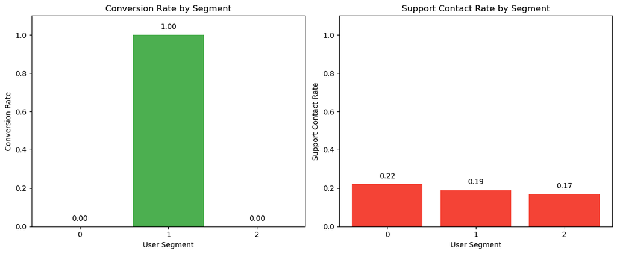

```python
# ✅ Step 3.3: Visualize Conversion & Support Rate by Cluster Segment

import matplotlib.pyplot as plt

# Extract data from the cluster_summary DataFrame
x_labels = cluster_summary['User_Segment'].astype(str)
conversion = cluster_summary['Conversion_Rate']
support = cluster_summary['Support_Rate']

# Create a side-by-side bar chart layout
plt.figure(figsize=(12, 5))

# ----------------------------
# Chart 1: Conversion Rate by Segment
# ----------------------------
plt.subplot(1, 2, 1)
plt.bar(x_labels, conversion, color="#4caf50")
plt.title("Conversion Rate by Segment")
plt.xlabel("User Segment")
plt.ylabel("Conversion Rate")
plt.ylim(0, 1.1)

# Add text labels on top of bars
for i, value in enumerate(conversion):
    plt.text(i, value + 0.03, f"{value:.2f}", ha='center', fontsize=10)

# ----------------------------
# Chart 2: Support Contact Rate by Segment
# ----------------------------
plt.subplot(1, 2, 2)
plt.bar(x_labels, support, color="#f44336")
plt.title("Support Contact Rate by Segment")
plt.xlabel("User Segment")
plt.ylabel("Support Contact Rate")
plt.ylim(0, 1.1)

# Add text labels on top of bars
for i, value in enumerate(support):
    plt.text(i, value + 0.03, f"{value:.2f}", ha='center', fontsize=10)

# ----------------------------
# Show both charts side by side
# ----------------------------
plt.tight_layout()
plt.show()
```

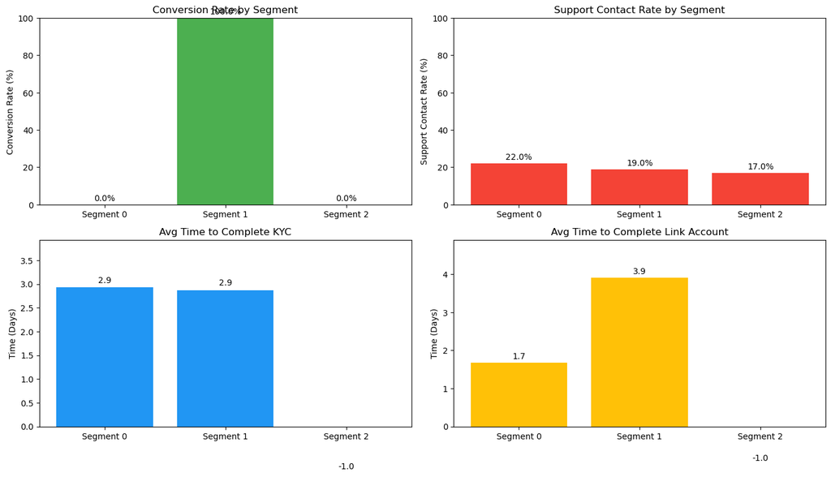

```python
import matplotlib.pyplot as plt

# ✅ 1. Prepare Data for Visualization (Conversion, Support, Time)
labels = ['Segment 0', 'Segment 1', 'Segment 2']
conversion = cluster_summary['Conversion_Rate'] * 100  # In percentage
support = cluster_summary['Support_Rate'] * 100  # In percentage
time_to_kyc = cluster_summary['Avg_Time_to_KYC']
time_kyc_to_link = cluster_summary['Avg_Time_KYC_to_Link']
time_link_to_txn = cluster_summary['Avg_Time_Link_to_Txn']

# 2. Create the Bar Charts (Side-by-side)
plt.figure(figsize=(14, 8))

# 2.1. Conversion Rate per Segment (Left)
plt.subplot(2, 2, 1)
plt.bar(labels, conversion, color="#4caf50")
plt.title("Conversion Rate by Segment")
plt.ylabel("Conversion Rate (%)")
plt.ylim(0, 100)
for i, v in enumerate(conversion):
    plt.text(i, v + 2, f"{v:.1f}%", ha='center', fontsize=10)

# 2.2. Support Rate per Segment (Right)
plt.subplot(2, 2, 2)
plt.bar(labels, support, color="#f44336")
plt.title("Support Contact Rate by Segment")
plt.ylabel("Support Contact Rate (%)")
plt.ylim(0, 100)
for i, v in enumerate(support):
    plt.text(i, v + 2, f"{v:.1f}%", ha='center', fontsize=10)

# 2.3. Average Time to KYC (Bottom Left)
plt.subplot(2, 2, 3)
plt.bar(labels, time_to_kyc, color="#2196f3")
plt.title("Avg Time to Complete KYC")
plt.ylabel("Time (Days)")
plt.ylim(0, max(time_to_kyc) + 1)
for i, v in enumerate(time_to_kyc):
    plt.text(i, v + 0.1, f"{v:.1f}", ha='center', fontsize=10)

# 2.4. Time Between KYC → Link (Bottom Right)
plt.subplot(2, 2, 4)
plt.bar(labels, time_kyc_to_link, color="#ffc107")
plt.title("Avg Time to Complete Link Account")
plt.ylabel("Time (Days)")
plt.ylim(0, max(time_kyc_to_link) + 1)
for i, v in enumerate(time_kyc_to_link):
    plt.text(i, v + 0.1, f"{v:.1f}", ha='center', fontsize=10)

# 3. Final layout settings
plt.tight_layout()
plt.show()
```

### 🔹 Step 4.1: Segment Revenue Analysis

```python
# ✅ Step 4.1: Segment Revenue Analysis

# 1. Filter users who actually completed a transaction and have transaction amount
txn_users = merged_df[merged_df['Txn_Amount'].notnull()]

# 2. Group by the clustered user segment
segment_revenue = txn_users.groupby('User_Segment').agg({
    'User_ID': 'count',            # How many users completed a transaction
    'Txn_Amount': ['sum', 'mean']  # Total and average transaction amount
})

# 3. Clean column names for easy reading
segment_revenue.columns = ['Txn_User_Count', 'Total_Revenue', 'Avg_Revenue_per_User']
segment_revenue = segment_revenue.reset_index()

# 4. Round values for presentation
segment_revenue = segment_revenue.round(2)

# 5. Preview the segment revenue breakdown
segment_revenue
```

|  | User_Segment | Txn_User_Count | Total_Revenue | Avg_Revenue_per_User |
| --- | --- | --- | --- | --- |
| 0 | 1 | 367 | 199401.13 | 543.33 |

| Segment | Txn Users | Total Revenue | Avg/User |
| --- | --- | --- | --- |
| 1 | 367 | ₹199,401.00 | ₹543.33 |
| 0 & 2 | 0 | ₹0.00 | ₹0.00 |

**🧠 Insight:**

Only Segment 1 generates revenue. That alone validates the clusters. It’s critical to retain and replicate this user group. This also proves that conversion equals value, not just clicks.

✅ Strategic Message:

Don’t optimize for more signups — optimize for Segment 1 behaviors Revenue can be traced to a very specific journey signature

## 📊 Step 4.2: Simulated Revenue Uplift

```python
# Rebuild segment_revenue safely
txn_users = merged_df[merged_df['Txn_Amount'].notnull()]

segment_revenue = txn_users.groupby('User_Segment').agg({
    'User_ID': 'count',
    'Txn_Amount': ['sum', 'mean']
})
segment_revenue.columns = ['Txn_User_Count', 'Total_Revenue', 'Avg_Revenue_per_User']
segment_revenue = segment_revenue.reset_index().round(2)
```

```python
# Step 1: Find the converting segment (conversion_rate > 0)
converting_segments = segment_revenue[segment_revenue['Txn_User_Count'] > 0]

# Step 2: If such a segment exists, use its average revenue
if not converting_segments.empty:
    # We'll just use the first converting segment found (usually there's only one)
    avg_value = converting_segments['Avg_Revenue_per_User'].values[0]
else:
    avg_value = 0

# Step 3: Pull users in Segment 2 and simulate 20% conversion
segment2_users = merged_df[merged_df['User_Segment'] == 2]
simulated_converted_users = int(len(segment2_users) * 0.20)
estimated_uplift = simulated_converted_users * avg_value

# Step 4: Print results
print("📊 Simulated Revenue Uplift if 20% of Segment 2 Converts")
print("--------------------------------------------------------")
print(f"Users recovered from Segment 2: {simulated_converted_users}")
print(f"Avg revenue per user (converted segment): ₹{avg_value:.2f}")
print(f"📈 Estimated total uplift: ₹{estimated_uplift:.2f}")
```

```
📊 Simulated Revenue Uplift if 20% of Segment 2 Converts
--------------------------------------------------------
Users recovered from Segment 2: 37
Avg revenue per user (converted segment): ₹543.33
📈 Estimated total uplift: ₹20103.21
```

- A simple what-if shows that recovering 20% of Segment 2 could yield ₹20K+.

> If 20% of Segment 2 converts using Segment 1’s avg spend:
- Simulated Users: 37
- Avg Value: ₹543.33
- **Estimated Uplift: ₹20,103.21**

## 📌 Final Takeaways

| Focus Area | Recommendation |
| --- | --- |
| Segment 1 (Happy Path) | Learn & scale |
| Segment 0 (Late Dropouts) | UX improvement, trust nudges |
| Segment 2 (Early Dropouts) | Improve onboarding or ignore for now |

## ✅ Summary

This project demonstrates:

- Behavioral funnel analytics
- Multi-source data integration
- User segmentation with KMeans
- Strategic revenue simulation
- Data storytelling with clean visuals

> 🎯 **Real-world impact:** Identify where money is lost, who’s dropping off, and where to optimize first — backed by both behavioral and financial evidence.